# Open Source as Institutional Infrastructure

Lessons from the UC OSPO Network

Tim Dennis

Data Science Center, UCLA Library

UCLA OSPO Lead, UC OSPO Network

## The invisible layer

Research data workflows run on open source:

- Data collection, cleaning, analysis, visualization
- Reproducibility tooling: containers, workflows, version control
- Repositories and scholarly infrastructure

**92%** of researchers use software; **69%** say their research would not be practical without it.

The people keeping it running are increasingly called **Research Software Engineers (RSEs)**, a growing professional community with no standard institutional home.

If every organization had to replace open source with proprietary equivalents, the cost would exceed **$8.8 trillion**.

Hettrick et al. (SSI, 2014/2022) · Hoffmann, Nagle & Zhou (2024) doi:10.2139/ssrn.4693148

[figure not shown]

Jupyter

[figure not shown]

Python

[figure not shown]

R

[figure not shown]

Git

[figure not shown]

Spark

[figure not shown]

Pandas

[figure not shown]

NumPy

[figure not shown]

Docker

[figure not shown]

Ray

[figure not shown]

ggplot2

[figure not shown]

dplyr

[figure not shown]

Snakemake

[figure not shown]

Nextflow

## The UC research-to-infrastructure pipeline

Data professionals built open data infrastructure: FAIR, DMPs, curation, provenance.

**FAIR4RS** is the same inflection point for software — and UC has been showing the way for 50 years.

BSD Unix · Ceph · Apache Spark · Jupyter · RISC-V · Ray

The pipeline from university research to global infrastructure is not rare or accidental.

Barker et al. (2022) doi:10.1038/s41597-022-01710-x

UC Berkeley

[figure not shown]

Jupyter

[figure not shown]

Apache Spark

[figure not shown]

RISC-V

[figure not shown]

Ray

[figure not shown]

BSD Unix

UC Santa Cruz

[figure not shown]

Ceph

UCSC Genome Browser

UC San Diego

Cytoscape EEGLAB

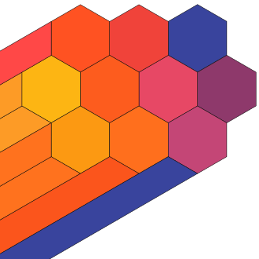

UCSD Pascal

UCLA

[figure not shown]

Processing

Named Data Networking

tz database

UC San Francisco

ChimeraX

[figure not shown]

OpenMM

UC Davis

[figure not shown]

sourmash

ERPLAB

## What is an academic OSPO?

An **Open Source Program Office** supports, governs, and promotes open source within an institution.

- Originated in industry: ~77% of large tech companies have one
- First academic OSPOs: Johns Hopkins, UC Santa Cruz, and RIT (2021)
- **34 academic OSPOs** in CURIOSS worldwide and growing
- Core functions: policy, licensing guidance, best practices, education, community

[interactive chart not shown]

🟠 UC OSPO Network · 🔵 CURIOSS member

## The UC OSPO Network

A **multi-campus collaboration** treating open source as shared infrastructure.

- 6 campuses: Santa Cruz, Berkeley, Davis, Los Angeles, Santa Barbara, San Diego
- Launched April 2024, funded by the Alfred P. Sloan Foundation
- **$1.85M** in external funding to date
- Lead: UC Santa Cruz, the first OSPO in a large state university system
- Serves 280,000+ students and 25,000+ faculty

Acts as a **neutral convener**: no single campus, company, or grant cycle can pull the work away.

Ruff (2026) UC Open Summit · youtu.be/eBriL3CDNeo

[interactive chart not shown]

## Discovery · Sustainability · Education

🔭

**Discovery**

Mapping who does what across the UC system

- 236,000+ repos scanned; ~82,000 institutionally affiliated
- 294-respondent system-wide survey
- UC Open Repository Browser (UC ORB)

🌱

**Sustainability**

Keeping projects and communities healthy

- **58%** of UC contributors are also maintainers
- Cross-campus licensing working group (UCOP + tech transfer)
- Project health assessment (OSSPREY)

📖

**Education**

Coordinated training across campuses

- Gap analysis → curriculum inventory → learning pathways
- Published at ucospo.net/education
- Coordinated with Carpentries infrastructure

Gomez et al. (2025) arxiv:2506.18359 · Scarlett et al. (2025) doi:10.31235/osf.io/p8bx6_v1

## Lessons from two years

What the network model enables that single campuses cannot:

1. **Shared staffing**: community manager, licensing specialist, technical roles
2. **Policy leverage**: the network has standing with UCOP; individual campuses do not
3. **Data at scale**: the GitHub and survey analyses require system-wide scope to mean anything
4. **Equity**: smaller campuses get services they could not build alone
5. **A replicable model**: $1.85M produced something other state systems can follow

Each campus contributes unique expertise; the network routes it to where it’s needed.

## Where this meets your work

For data professionals, the OSPO sits at the intersection of:

- Research software engineering ↔︎ data management
- Licensing compliance ↔︎ open data policy
- Reproducibility tooling ↔︎ FAIR / FAIR4RS
- Training infrastructure ↔︎ data literacy programs
- RSE community ↔︎ library research support

**For your institution:**

- Where does open source software governance currently live?
- What would it take to treat it as infrastructure rather than a side project?

## You’re already doing this work

If you do technical data services, researchers are already bringing you these questions:

- “What license should I use for this code?”
- “Is this library still maintained? Should I depend on it?”
- “How do I make this reproducible and citable?”
- “My funder wants a software management plan.”
- “How do I accept contributions from collaborators?”

**That is OSPO work.** The frame makes it legible to your institution.

**The network has already built the resources** (Laura Langdon, UC OSPO):

[`README`](https://ucospo.net/oss-resources/template-guides/readme-guide/) · [`LICENSE`](https://ucospo.net/oss-resources/template-guides/license-guide/) · [`CONTRIBUTING`](https://ucospo.net/oss-resources/template-guides/contributing-guide/) · [`CODE_OF_CONDUCT`](https://ucospo.net/oss-resources/template-guides/code-of-conduct-guide/) · `CITATION.cff` + Zenodo DOI · [Growing a Community](https://ucospo.net/oss-resources/growing-community/) · [Carpentries Incubator lesson](https://ucospo.net/research-software-citable-discoverable/)

**Raise the floor, not just solve the ticket**

Fixing their immediate problem gets them through the week.

Moving them from “it runs on my machine” to maintainable, licensed, citable software gets their whole lab there, and their students after them.

You don’t need a formal OSPO to do this. You need the frame.

**OSPO heuristics already in your toolkit:** health signals · bus factor · governance files · FAIR4RS · software DMPs · contributor conventions · community governance

## Learn more / connect

**UC OSPO Network:** ucospo.net

- Education site: ucospo.net/education
- Mailing list, Slack, events calendar

**Global network:** curioss.org, 34 academic OSPOs worldwide and growing

**Tim Dennis** Data Science Center, UCLA Library orcid.org/0000-0001-6632-3812 tdennis@library.ucla.edu

🖥 Slides: **tinyurl.com/iassist2026**

📄 Handout: **tinyurl.com/iassist2026-handout**

📑 PDF: **[download on Zenodo](https://zenodo.org/records/20498692)**

🔗 DOI: **10.5281/zenodo.20498692**

[figure not shown]

QR code linking to tinyurl.com/iassist2026 — slides for this presentation

tinyurl.com/iassist2026

## References

Barker, M., Chue Hong, N. P., Katz, D. S., Lamprecht, A.-L., Martinez-Ortiz, C., Psomopoulos, F., Harrow, J., Castro, L. J., Gruenpeter, M., Martinez, P. A., & Honeyman, T. (2022). Introducing the FAIR principles for research software. *Scientific Data*, *9*, 622. https://doi.org/10.1038/s41597-022-01710-x

Brown, C. T., & Irber, L. (2016). Sourmash: A library for MinHash sketching of DNA. *Journal of Open Source Software*, *1*(5), 27. https://doi.org/10.21105/joss.00027

Cerf, V. G., & Kahn, R. E. (1974). A protocol for packet network intercommunication. *IEEE Transactions on Communications*, *22*(5), 637–648. https://doi.org/10.1109/TCOM.1974.1092259

Delorme, A., & Makeig, S. (2004). EEGLAB: An open source toolbox for analysis of single-trial EEG dynamics including independent component analysis. *Journal of Neuroscience Methods*, *134*(1), 9–21. https://doi.org/10.1016/j.jneumeth.2003.10.009

Eastman, P., Swails, J., Chodera, J. D., McGibbon, R. T., Zhao, Y., Beauchamp, K. A., Wang, L.-P., Simmonett, A. C., Harrigan, M. P., Stern, C. D., Wiewiora, R. P., Brooks, B. R., & Pande, V. S. (2017). OpenMM 7: Rapid development of high performance algorithms for molecular dynamics. *PLOS Computational Biology*, *13*(7), e1005659. https://doi.org/10.1371/journal.pcbi.1005659

Gomez, J., Lovell, E., Lieggi, S., Cardenas, A. A., & Davis, J. (2025). *Recipe for discovery: A pipeline for institutional open source activity*. https://arxiv.org/abs/2506.18359

Hettrick, S., Antonioletti, M., Carr, L., Chue Hong, N., Crouch, S., De Roure, D., Emsley, I., Goble, C., Hay, A., Inupakutika, D., et al. (2014). *UK Research Software Survey 2014*. Software Sustainability Institute. https://doi.org/10.5281/zenodo.14809

Hoffmann, M., Nagle, F., & Zhou, Y. (2024). *The value of open source software* (Working Paper Nos. 24-038). Harvard Business School. https://doi.org/10.2139/ssrn.4693148

Kent, W. J., Sugnet, C. W., Furey, T. S., Roskin, K. M., Pringle, T. H., Zahler, A. M., & Haussler, D. (2002). The human genome browser at UCSC. *Genome Research*, *12*(6), 996–1006. https://doi.org/10.1101/gr.229102

Kluyver, T., Ragan-Kelley, B., Pérez, F., Granger, B., Bussonnier, M., Frederic, J., Kelley, K., Hamrick, J., Grout, J., Corlay, S., Ivanov, P., Avila, D., Abdalla, S., & Willing, C. (2016). Jupyter Notebooks — a publishing format for reproducible computational workflows. In F. Loizides & B. Schmidt (Eds.), *Positioning and power in academic publishing: Players, agents and agendas* (pp. 87–90). IOS Press. https://doi.org/10.3233/978-1-61499-649-1-87

Moritz, P., Nishihara, R., Wang, S., Tumanov, A., Liaw, R., Liang, E., Elibol, M., Yang, Z., Paul, W., Jordan, M. I., & Stoica, I. (2018). Ray: A distributed framework for emerging AI applications. *13th USENIX Symposium on Operating Systems Design and Implementation (OSDI)*, 561–577.

Olson, A. D., & Eggert, P. (1986). *tz database (IANA time zone database)*. IANA. https://www.iana.org/time-zones

Ruff, N. (2026). *The role of foundations in advancing open collaboration and innovation*. UC Open Summit. https://youtu.be/eBriL3CDNeo

Scarlett, V., Curty, R. G., Gomez, J., Langdon, L., Janée, G., & Budden, A. E. (2025). *A system-wide snapshot: A multi-campus survey of open source contributors at the University of California*. SocArXiv. https://doi.org/10.31235/osf.io/p8bx6_v1

Shannon, P., Markiel, A., Ozier, O., Baliga, N. S., Wang, J. T., Ramage, D., Amin, N., Schwikowski, B., & Ideker, T. (2003). Cytoscape: A software environment for integrated models of biomolecular interaction networks. *Genome Research*, *13*(11), 2498–2504. https://doi.org/10.1101/gr.1239303

Stonebraker, M., & Rowe, L. A. (1987). *The design of POSTGRES* (UCB/ERL M86/85). University of California, Berkeley.

Stonebraker, M., Wong, E., Kreps, P., & Held, G. (1976). The design and implementation of INGRES. *ACM Transactions on Database Systems*, *1*(3), 189–222. https://doi.org/10.1145/320473.320476

Tidelift. (2024). *The 2024 Tidelift maintainer impact report*. Tidelift. https://dev.to/tidelift/the-open-source-maintainer-community-is-getting-grayer-1gc2

Waterman, A., & Asanović, K. (2019). *The RISC-V instruction set manual, volume I: Unprivileged ISA*. RISC-V Foundation. https://github.com/riscv/riscv-isa-manual

Weil, S. A., Brandt, S. A., Miller, E. L., Long, D. D. E., & Maltzahn, C. (2006). Ceph: A scalable, high-performance distributed file system. *7th USENIX Symposium on Operating Systems Design and Implementation (OSDI)*, 307–320.

Zaharia, M., Chowdhury, M., Das, T., Dave, A., Ma, J., McCauly, M., Franklin, M. J., Shenker, S., & Stoica, I. (2012). Resilient distributed datasets: A fault-tolerant abstraction for in-memory cluster computing. *9th USENIX Symposium on Networked Systems Design and Implementation (NSDI)*, 15–28.

Zhang, L., Afanasyev, A., Burke, J., Jacobson, V., claffy, kc, Crowley, P., Papadopoulos, C., Wang, L., & Zhang, B. (2014). Named data networking. *ACM SIGCOMM Computer Communication Review*, *44*(3), 66–73. https://doi.org/10.1145/2656877.2656887